# Reproducible Research: Peer Assessment 1

first loading of neccesary packages are required

```r
library(lubridate)
```

```r
library(ggplot2)
library(plyr)
```

## Loading and preprocessing the data

loading the data into the R envrionment

```r
activity<-read.csv("./activity/activity.csv")
```

transform the dates to class date

```r
activity$date<-ymd(activity$date)
```

## What is mean total number of steps taken per day?

missing values are ignored for this part of the analysis

calculation of the total number of steps taken each day

```r
stepsperday<-aggregate(steps~date, activity ,sum)
```

histogram of the total number of steps taken per day

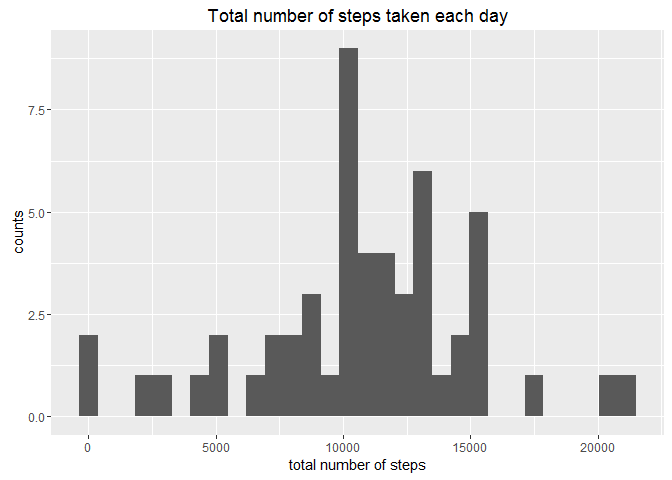

```r
ggplot(stepsperday, aes(steps))+geom_histogram(bins=30)+
        labs(y="counts", x="total number of steps")+
        ggtitle("Total number of steps taken each day")
```

mean and median of total numbers of steps taken per day

```r
meansteps<-mean(stepsperday$steps, na.rm =TRUE)
mediansteps<-median(stepsperday$steps, na.rm=TRUE)
data.frame(mean=meansteps, median=mediansteps)
```

```
##       mean median
## 1 10766.19  10765
```

## What is the average daily activity pattern?

```r
interval<-aggregate(steps~interval,activity, mean, na.rm=TRUE)
```

time series plot of the interval and the average steps taken

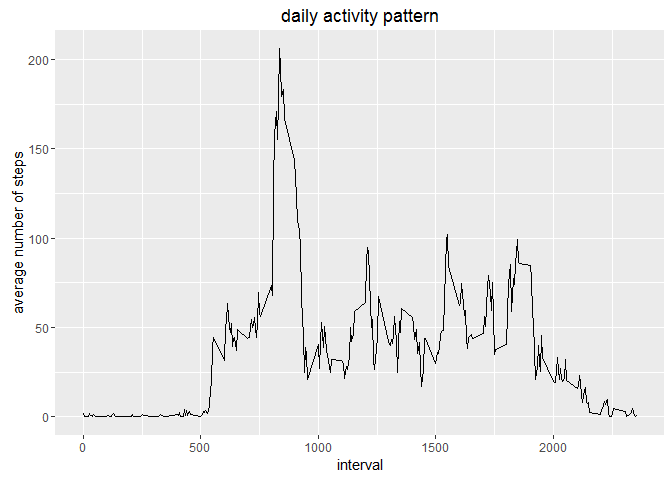

```r
ggplot(interval, aes(x=interval, y=steps))+geom_line()+
        labs(y="average number of steps", x="interval")+
        ggtitle("daily activity pattern")
```

```r
sapply(interval, max)
```

```
##  interval     steps
## 2355.0000  206.1698
```

## Imputing missing values

number of missing values in the data set (total number of rows with NA)

```r
NNAs<-count(complete.cases(activity))
NNAs[1,2]
```

```
## [1] 2304
```

function to replace NA with the mean

```r
impute.mean <- function(x) replace(x, is.na(x), mean(x, na.rm = TRUE))
```

replace the NAs with the mean of steps of the corresponding 5-minute interval

```r
activityNA <- ddply(activity, ~ interval, transform, steps=impute.mean(steps))
```

calculation of the total number of steps taken each day

```r
stepsperdayNA<-aggregate(steps~date, activityNA,sum)
```

combining the datasets of data with NA and without NA

```r
stepsperday$group <- "with NA"
stepsperdayNA$group <- "without NA"
dfboth <- rbind(stepsperday,stepsperdayNA)
```

histogram for the data with and without NA

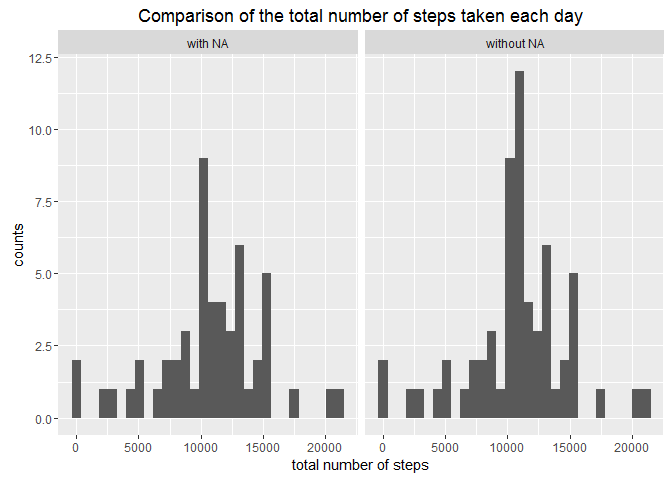

```r
ggplot(dfboth, aes(x=steps)) +
        geom_histogram(bins=30) +
        facet_grid(.~group)+
        labs(y="counts", x="total number of steps")+
        ggtitle("Comparison of the total number of steps taken each day")
```

comparison of median and mean of the data with NAs and without NAs

```r
meanstepsNA<-mean(stepsperdayNA$steps, na.rm =TRUE)
medianstepsNA<-median(stepsperdayNA$steps, na.rm=TRUE)
tabNA<-data.frame(mean=c(meansteps,meanstepsNA), median=c(mediansteps, medianstepsNA), row.names=c("with NA", "whithout NA"))
tabNA
```

```
##                 mean   median
## with NA     10766.19 10765.00
## whithout NA 10766.19 10766.19
```

- imputing of the missing values with the mean of steps did not have an effect on the mean but had a small effect on the median
- the main impact lays more in higher counts on the value that represents the mean in the data

## Are there differences in activity patterns between weekdays and weekends?

translation of the dates to weekday

```r
activityNA$weekdays<-weekdays(activityNA$date)
```

create a new variable weekend

```r
activityNA$weekend<-1
```

fill in the new variable with weekday and weekend corresponding to the day of the week (not the german words for the weekdays)

```r
for (i in 1:17568) {
        if (activityNA[i,4]=="Montag" |
            activityNA[i,4]=="Dienstag" |
            activityNA[i,4]=="Mittwoch" |
            activityNA[i,4]=="Donnerstag" |
            activityNA[i,4]=="Freitag")
            {activityNA[i,5]<-c("weekday")}
        else {activityNA[i,5]<-c("weekend")}
        }
```

caculate the average number of steps for weekdays and weekends for each 5-minute interval

```r
activityNA$weekend<-as.factor(activityNA$weekend)
df<-aggregate(steps~weekend+interval, activityNA, mean)
```

time series plots of the 5-minute interval and the average number of steps taken across weekdays and weekends

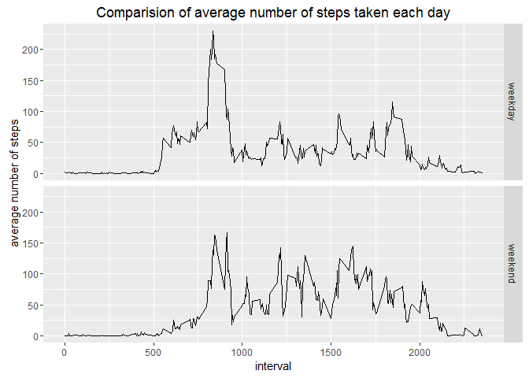

```r
ggplot(df, aes(x=interval, y=steps))+geom_line()+facet_grid(weekend~.)+
        labs(y="average number of steps", x="interval")+
        ggtitle("Comparision of average number of steps taken each day")
```